# Exercise 3_1: Basic Maps

Introduction to Geospatial Techniques for Social Scientists in R

Author

Stefan Jünger & Dennis Abel

### Exercises

We’ve finally arrived at creating our first maps based on the data we imported and cleaned in the previous sessions. The focus of this first session lies on the package `tmap` to create maps.

**🏋 Exercise 1**

Let’s start with some data wrangling. Import the German district data `./data/VG250_KRS.shp` using the function `sf::read_sf()` and the spreadsheet data `../data/attributes_districts.csv` which contains additional attributes. Join them using the column `AGS`. Finally, create a map with only the outline of Germany and one where the districts’ borders are visible. Choose a color of your choice for both maps.

**💡 Tip**

If you’re stuck with the data wrangling, try this code:

```r
# load libraries
library(dplyr)
library(readr)
library(sf)
library(tmap)

# load district shapefile
german_districts <- sf::read_sf("./data/VG250_KRS.shp")

# load district attributes
attributes_districts <- readr::read_csv2("./data/attributes_districts.csv")

# join data
german_districts_enhanced <-
  german_districts |>
  dplyr::left_join(attributes_districts, by = "AGS")
```

**🏋 Exercise 2**

In the second step, we want to visualize some information on the German districts contained in the attribute table. Choose a column of interest and create a map. Alternate the map by:

- add a legend title and change the color palette
- add a title to the map and change the font color of the title

Assign your map to an object called `ger_map`.

**💡 Tip**

Combine the following options with a plus sign:

- add a legend title and change the color palette: `tm_fill(fill = "", fill.legend = tm_legend(title = ""), fill.scale = tm_scale_continuous(values = "")) +`
- add a title to the map and change the font color of the title: `tm_title(text = "", color = "") +`

If you run `cols4all::c4a_gui()`, R fires up a nice graphical interface to search for colors.

**💡 Tip**

To assign your map to an object, use the arrow `<-`.

### Solutions

**✅ Solution 1**

```r
# load libraries
library(dplyr)
library(readr)
library(sf)
library(tmap)

# load district shapefile
german_districts <- sf::read_sf("./data/VG250_KRS.shp")

# load district attributes
attributes_districts <- readr::read_csv2("./data/attributes_districts.csv")

# join data
german_districts_enhanced <-
  german_districts |>
  dplyr::left_join(attributes_districts, by = "AGS")

# first maps based on geometrc features
tm_shape(german_districts_enhanced) + # call  the shapefile first
  tm_fill() # fills the polygons without drawing borders

# ... or use tm_polygons
tm_shape(german_districts_enhanced) +
  tm_polygons(col = "lightblue") # fills the polygons and draws borders
```

```
ℹ Using "','" as decimal and "'.'" as grouping mark. Use `read_delim()` for more control.
```

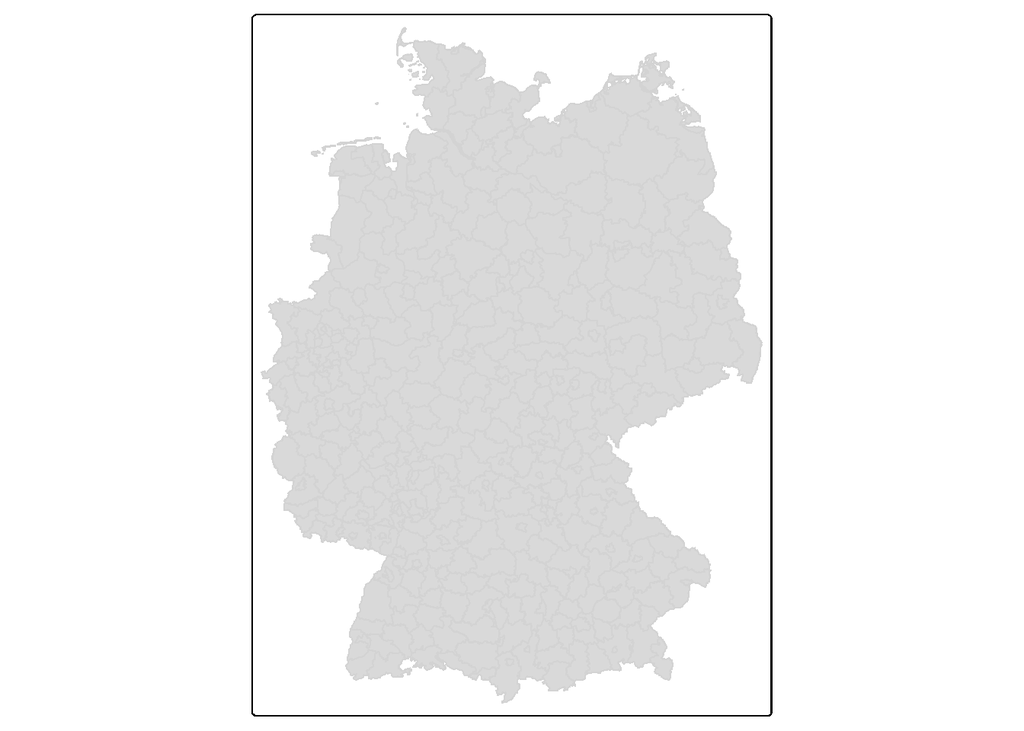

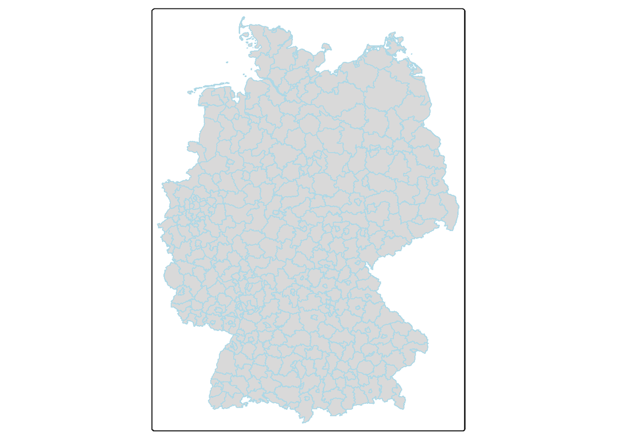

**✅ Solution 2**

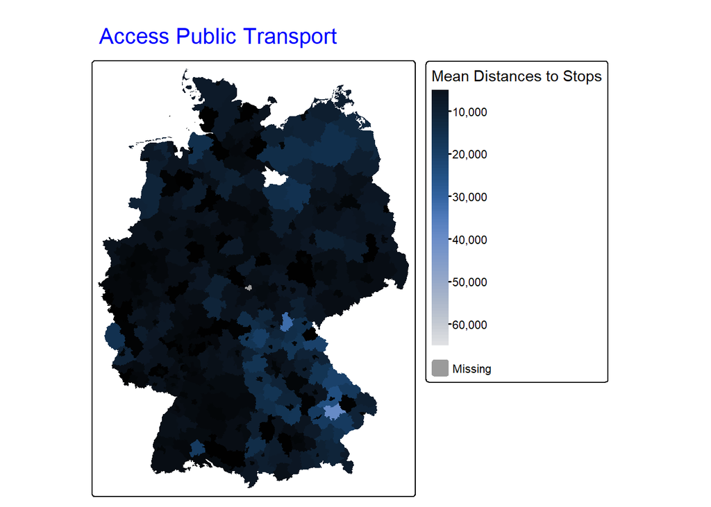

```r
ger_map <-
  tm_shape(german_districts_enhanced) +
  tm_fill(
    fill = "publictransport_meandist", # "col" can be the name of a color or a column name
    fill.legend = tm_legend(title = "Mean Distances to Stops"), # add a title to the legend
    fill.scale = tm_scale_continuous(values = "oslo") # add palette
  )  +
  tm_title(
    text = "Access Public Transport",  # alternate the overall layout like title
    color = "blue" # changes the font color of the title +
  )

ger_map
```